# Divvy Data Project

Matthew Mahoney

```css
button { text-align:left;}
```

## Import libraries

```r
library(remotes)
library(ggmap)
library(tidyverse)
library(lubridate)
library(maps)
library(ggthemes)
library(ggrepel)
library(data.table)
library(broom)
library(gridExtra)
library(knitr)
```

## Data Import

```r
## Data Import

list.files(pattern = 'd_ride') %>%
  map_df(~fread(header = FALSE, .)) -> d_ride_table

r_station_lat_lng <- read.csv(
"cyclistic_r_station_lat_lon.csv",
                              header = FALSE)
r_station_table <- read.csv(
  "cyclistic_r_station_table.csv",
                            header = FALSE)

setDT(d_ride_table)

### rename columns

names(r_station_lat_lng) <- c('station_id', 'lat', 'lon')
names(d_ride_table) <- c('ride_id', 'rideable_type', 'started_at', 'ended_at',
                         'start_station_id', 'end_station_id',
                         'member_casual', 'ride_in_seconds',
                         'ride_length', 'year_of_ride', 'month_of_ride',
                         'day_of_week')
names(r_station_table) <- c('station_name', 'station_key')

### reclassify datetimes as POSIX
d_ride_table$started_at <- as_datetime(d_ride_table$started_at)
d_ride_table$ended_at <- as_datetime(d_ride_table$ended_at)
```

## Analysis

### Plots

Following data import and table creation, I begin my analysis finding the average ride length and the mode of the day of week for each group using the service.

```r
## find avg length of ride and the day of week mode for casual riders
mean(d_ride_table_c$ride_in_seconds)/60 -> avg_ride_length_casual
getmode(d_ride_table_c$day_of_week) -> mode_dow_c


## find avg length of ride and the day of week mode for members
mean(d_ride_table_m$ride_in_seconds)/60 -> avg_ride_length_member
getmode(d_ride_table_m$day_of_week) -> mode_dow_m

mode_dow_c <- getDateString(mode_dow_c)
mode_dow_m <- getDateString(mode_dow_m)
```

We find that for casual riders, the most common riding day is Saturday, and the most common day for members is Tuesday.

This is an interesting insight already, and leads me to believe that it may be possible that casual riders are riding more on weekends because they do not use the service to commute to a job.

Continuing on this path, I create a table that contains the average ride length by day for both members and casual riders, and also one that checks the number of rides by day of week over 12 months of data.

```r
## find avg ride length by day for members and store in a table
d_ride_table %>%
  subset(select = c(day_of_week, ride_in_seconds, member_casual)) %>%
  group_by(day_of_week, member_casual) %>%
  summarize(avg_ride = round(mean(ride_in_seconds)/60,
                             digits= 3)) -> a

d_avg_ride_by_day$ride_length <- a$avg_ride
d_avg_ride_by_day$member_type <- a$member_casual

rm(a)
```

Graphing these leads to an interesting insight.

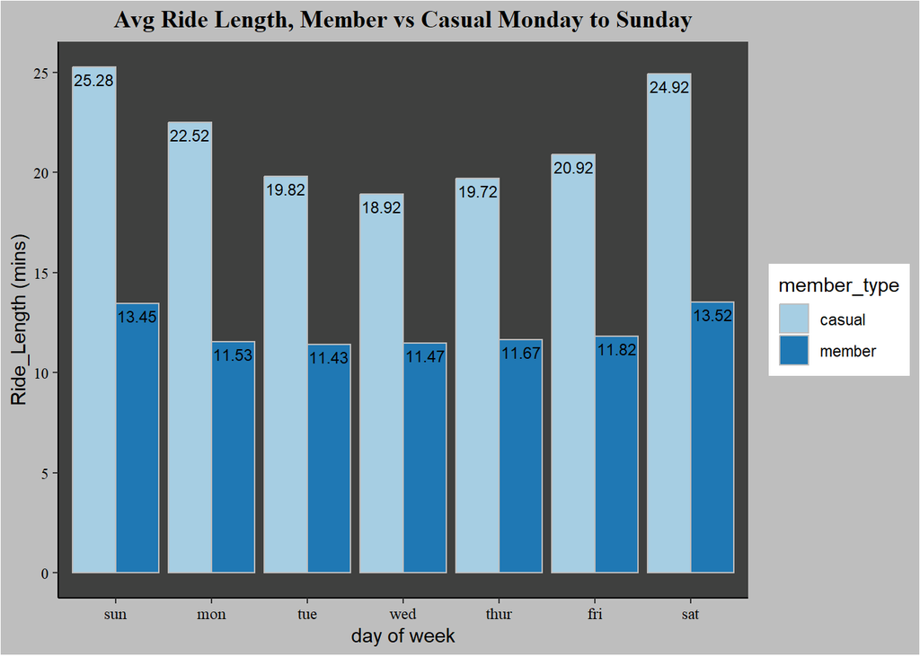

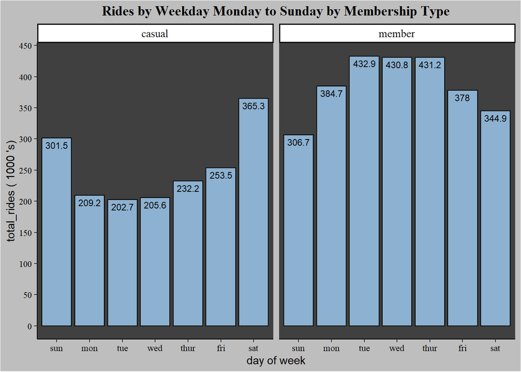

The above graphs show that members take shorter more consistent rides, and also ride more frequently during the week days, while casual riders take longer more varied rides, and ride more during the weekends. This makes a strong case that members use the service for activities like commuting or scheduled exercise, while casual riders likely use the service more commonly for joy riding, or weekend activities.

Next I want to take a look at seasonal ridership, to do this, I create a new table that contains a count of rides taken by the two rider types in each season.

Additional code hidden here.

```r
## Loop to generate values for season, ride_count, and member_type
for (j in 1:4){ #begin for

  sm <- sm + 3 ## add 3 to both values to get next season range
  em <- em + 3


d_ride_table_c %>%
  filter(month_of_ride >= sm & month_of_ride <= em) %>% ## filter for month range
  summarize(count_r = n()) -> a

ride_count <- append(ride_count, a$count_r) ##append to vectors
season <- append(season, j)
member_type <- append(member_type, 'casual')

d_ride_table_m %>%
  ## filter for month range
  filter(month_of_ride >= sm & month_of_ride <= em) %>%
  summarize(count_r = n()) -> b

ride_count <- append(ride_count, b$count_r) ##append to vectors
season <- append(season, j)
member_type <- append(member_type, 'member')

  rm(a,b)

} # end for
```

```r
#create new data frame with vectors
d_rides_by_season <- data.frame(season, ride_count, member_type)

rm(sm,em,j, season, ride_count, member_type)
```

Visualizing this data, we find what we would likely expect, especially considering the weather patterns in a place like Chicago.

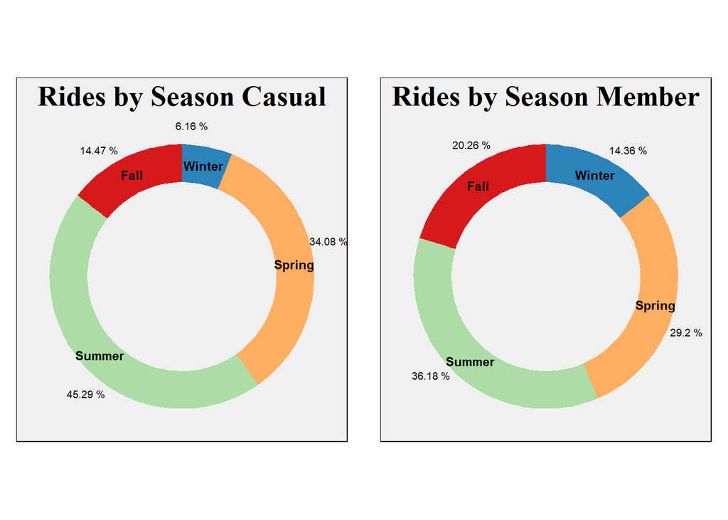

We find that generally ridership is dispersed equally for casual riders and members. However, members do ride more in colder months than casual riders do. Though this is a relatively small difference, it could suggest that members do choose to ride more even in the colder months as they use the service for necessary tasks like commuting.

The final relationship I’d like to take a look at is the types of bikes that casual riders and members use.

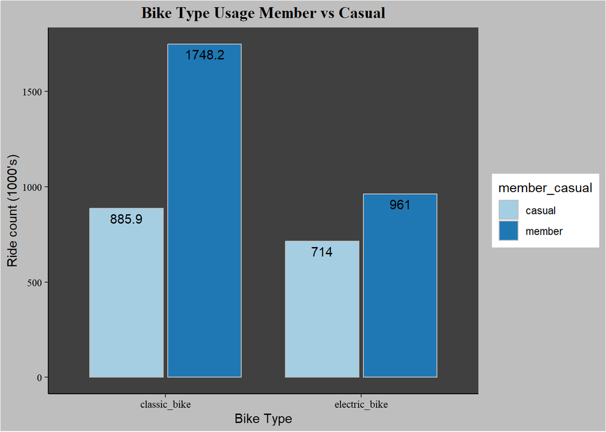

Casual members use classic bikes 55.37% of the time and electric bikes 44.63% of the time, while members use classic bikes 64.53% of the time and electric bikes 35.47% of the time.

This is also reflected in the visualization of the counts above. We can clearly see that even though members use the service at higher rates, their usage shows a preference to classic bikes.

Another thing to look at is rides during time of day. I start by taking a large sample of 100,000 from the main dataset `d_ride_table` and create a plot for which hours of the day casual riders/members use bikes the most.

```r
d_ride_table_sample <- sample_n(d_ride_table,100000) %>%
  subset(select = c(member_casual, started_at,ended_at)) %>%
  mutate(hour_of_ride = format(as.POSIXct(started_at), format = "%H"))

d_ride_table_sample$hour_of_ride <- as.numeric(d_ride_table_sample$hour_of_ride)

d_hour_of_day_table <- d_ride_table_sample %>%
  group_by(member_casual) %>%
  count(hour_of_ride) %>%
  mutate(ridesPercent = n/sum(n)*100)
```

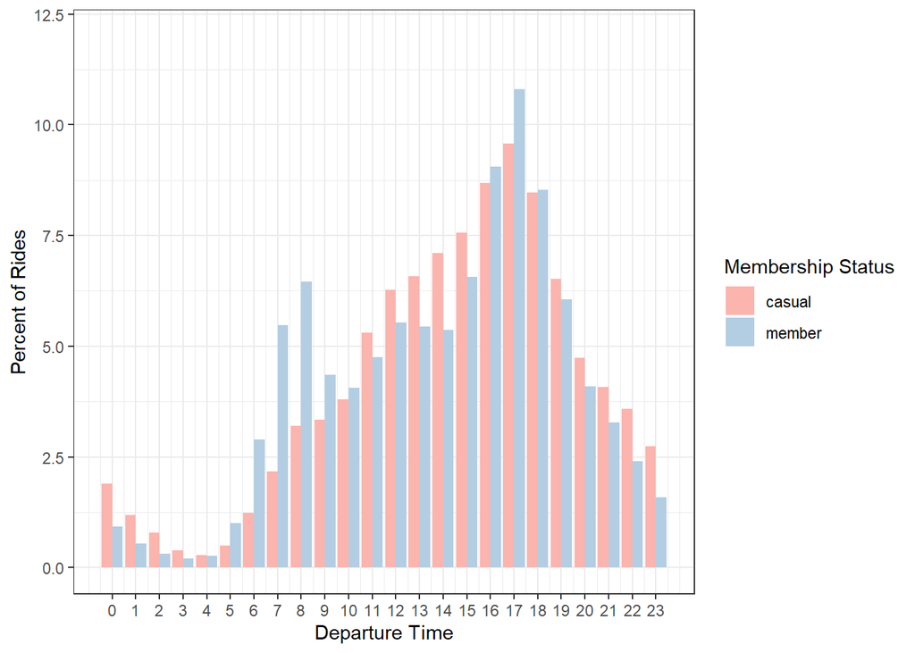

```r
##Plot bike type usage for both casual and member riders by percent
d_hour_of_day_table %>%
    ggplot(aes(x=hour_of_ride, y = ridesPercent, fill = member_casual,
                                  group = member_casual)) +
    geom_bar(stat = 'identity', position = position_dodge(0.9)) +
    scale_x_continuous(breaks = seq(0,23,1)) +
    ylim(0,12) +
    scale_fill_brewer(palette = "Pastel1") +
    labs(x = 'Departure Time', y = 'Percent of Rides',
         fill = 'Membership Status' ) +
    theme_bw()
```

### Statistical Tests

```r
d_hour_of_day_table$hour_of_ride <- as.factor(d_hour_of_day_table$hour_of_ride)
d_hour_of_day_table$member_casual<- as.factor(d_hour_of_day_table$member_casual)
```

```r
d_hour_of_day_table %>%
  select(member_casual, n) %>%
  t.test(n ~ member_casual, .)
```

```
##
##  Welch Two Sample t-test
##
## data:  n by member_casual
## t = -1.9234, df = 39.564, p-value = 0.06165
## alternative hypothesis: true difference in means between group casual and group member is not equal to 0
## 95 percent confidence interval:
##  -1700.23977    42.40644
## sample estimates:
## mean in group casual mean in group member
##             1668.875             2497.792
```

```r
d_hour_of_day_table %>%
  aov(n ~ hour_of_ride + member_casual, .) %>%
  summary()
```

```
##               Df   Sum Sq Mean Sq F value   Pr(>F)
## hour_of_ride  23 93517203 4065965   10.38 2.04e-07 ***
## member_casual  1  8245234 8245234   21.05  0.00013 ***
## Residuals     23  9008786  391686
## ---
## Signif. codes:  0 '***' 0.001 '**' 0.01 '*' 0.05 '.' 0.1 ' ' 1
```

```r
t_test_avg_ride_length <- d_ride_table %>%
  select(ride_in_seconds, day_of_week, member_casual) %>%
  group_by(day_of_week, member_casual) %>%
  summarize(mean_ride_length = mean(ride_in_seconds)/60) %>%
  t.test(mean_ride_length ~ member_casual, .)
```

We find that there is a real difference between the average ride lengths for members and casual riders across all data, with a p-value of 2.128273^{-5}

```r
d_ride_table %>%
  select(member_casual, day_of_week) %>%
  table() %>%
  chisq.test()
```

```
##
##  Pearson's Chi-squared test
##
## data:  .
## X-squared = 107547, df = 6, p-value < 2.2e-16
```

### Mapping

```r
## Create tables for the top ten trips for casual and member riders

top_ten_trips_c <- trip_totals(d_station_trip_totals, 'casual')
top_ten_trips_m <- trip_totals(d_station_trip_totals, 'member')
```

```r
## using openstreetmap for bounding box info for

chicago_map <- get_stadiamap(
  bbox = c(left = -87.73, bottom = 41.76, right = -87.57, top = 41.97),
  maptype='stamen_terrain',
  zoom = 13) %>% ggmap()
```

I’ve mapped all station locations within the main Chicago metropolitan area so we can see the general distribution of the stations.

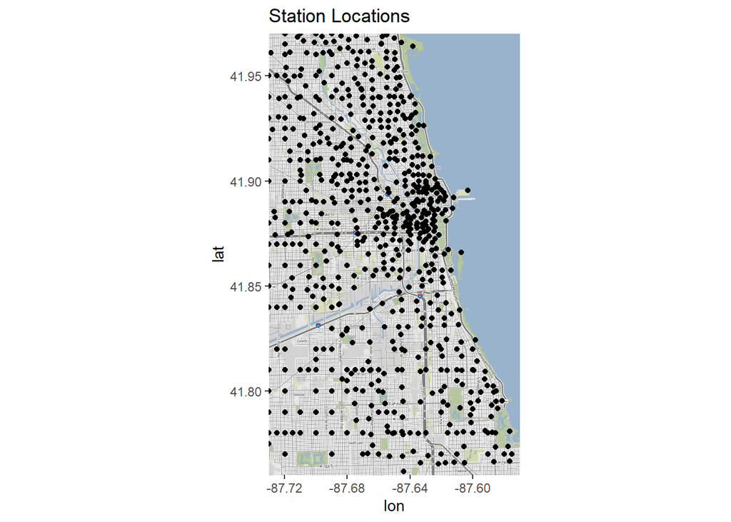

```r
## Map all stations within the bounds of the top 10
chicago_map +
  geom_point(data = r_station_lat_lng, aes(x = lon, y = lat))+
  ggtitle(label = 'Station Locations')
```

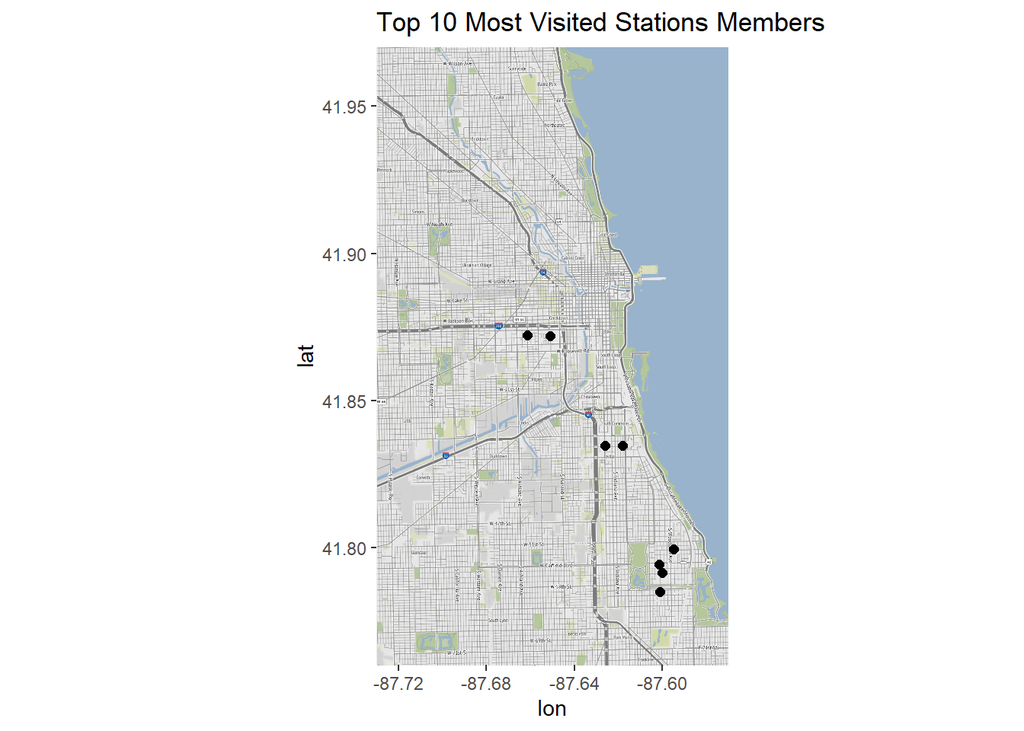

```r
## Map start/end station locations for the top 10 trips taken by members
chicago_map +
  geom_point(data = top_ten_trips_m
             ,aes(x = lon.x, y=lat.x),size = 2)+
  ggtitle(label = 'Top 10 Most Visited Stations Members') +
  geom_point(data = top_ten_trips_m,
             aes(x = lon.y, y = lat.y),size =2)+
  theme(legend.position = "none")
```

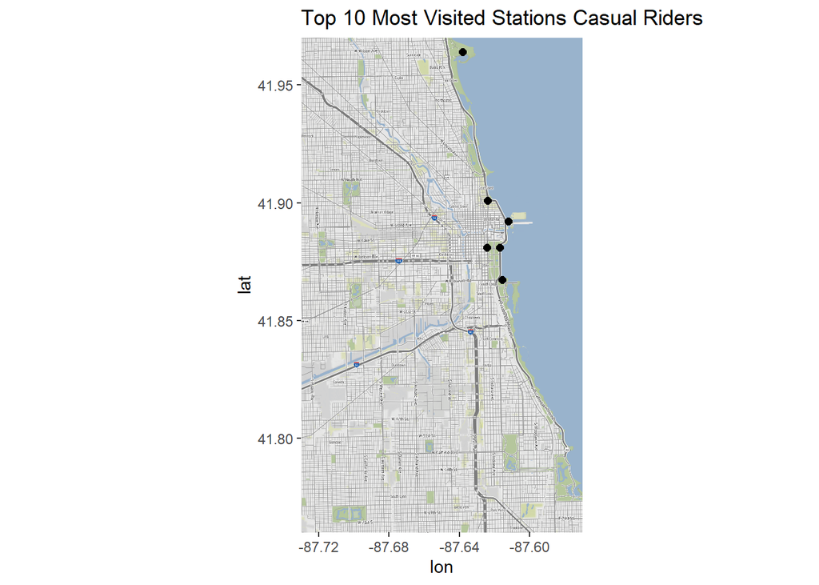

```r
## Map start/end station locations for the top 10 trips taken by
## casual riders
chicago_map +
  geom_point(data = top_ten_trips_c
             ,aes(x = lon.x, y=lat.x),size = 2)+
  ggtitle(label = 'Top 10 Most Visited Stations Casual Riders') +
  geom_point(data = top_ten_trips_c,
             aes(x = lon.y, y = lat.y),size =2)+
  theme(legend.position = "none")
```

### Table Index

| ride_id | rideable_type | started_at | ended_at | start_station_id | end_station_id | member_casual | ride_in_seconds | ride_length | year_of_ride | month_of_ride | day_of_week |
| --- | --- | --- | --- | --- | --- | --- | --- | --- | --- | --- | --- |
| 1F4DB726DD82F05C | electric_bike | 2022-05-22 07:48:48 | 2022-05-22 08:02:49 | 1025 | 977 | casual | 841 | 00:14:01.0000000 | 2022 | 5 | 1 |
| 1F4DB7AD2E34FD69 | classic_bike | 2022-09-23 22:29:03 | 2022-09-23 22:46:22 | 1127 | 1183 | casual | 1039 | 00:17:19.0000000 | 2022 | 9 | 6 |
| 1F4DBA20BD2FEA3A | classic_bike | 2022-04-23 14:49:32 | 2022-04-23 14:54:37 | 901 | 679 | casual | 305 | 00:05:05.0000000 | 2022 | 4 | 7 |
| 1F4DBC71EBDC5A48 | classic_bike | 2022-07-31 11:14:55 | 2022-07-31 11:31:52 | 161 | 1093 | casual | 1017 | 00:16:57.0000000 | 2022 | 7 | 1 |
| 1F4DCA3E96379370 | classic_bike | 2022-08-04 22:09:53 | 2022-08-04 22:31:16 | 77 | 370 | casual | 1283 | 00:21:23.0000000 | 2022 | 8 | 5 |

| ride_id | rideable_type | started_at | ended_at | start_station_id | end_station_id | member_casual | ride_in_seconds | ride_length | year_of_ride | month_of_ride | day_of_week |
| --- | --- | --- | --- | --- | --- | --- | --- | --- | --- | --- | --- |
| 1F4DBF64AEB04D11 | electric_bike | 2022-06-16 23:48:22 | 2022-06-17 00:03:08 | 1075 | 1361 | member | 886 | 00:14:46.0000000 | 2022 | 6 | 5 |
| 1F4DC300A7E48C37 | classic_bike | 2022-07-10 16:48:33 | 2022-07-10 17:26:49 | 1093 | 1254 | member | 2296 | 00:38:16.0000000 | 2022 | 7 | 1 |
| 1F4DC33D55B4D23B | electric_bike | 2022-07-14 06:37:23 | 2022-07-14 06:45:21 | 359 | 740 | member | 478 | 00:07:58.0000000 | 2022 | 7 | 5 |
| 1F4DC769DEC8960A | classic_bike | 2022-05-04 16:15:32 | 2022-05-04 16:15:51 | 638 | 638 | member | 19 | 00:00:19.0000000 | 2022 | 5 | 4 |
| 1F4DD3939267AEF9 | electric_bike | 2022-11-01 16:36:51 | 2022-11-01 16:42:19 | 835 | 1188 | member | 328 | 00:05:28.0000000 | 2022 | 11 | 3 |

| pair_id | start_station_name | start_station_id | end_station_name | end_station_id |
| --- | --- | --- | --- | --- |
| 171376 | Langley Ave & 49th St | 615 | 53rd St & Indiana Ave | 1 |
| 137066 | 63rd & Western Ave N | 2 | 63rd & Western Ave N | 2 |
| 172250 | Western Blvd & 48th Pl | 177 | 63rd & Western Ave N | 2 |
| 120438 | Ashland Ave & 63rd St | 880 | 63rd & Western Ave N | 2 |
| 1913 | Aberdeen St & Jackson Blvd | 3 | Aberdeen St & Jackson Blvd | 3 |

| pair_id | trip_count | member_type |
| --- | --- | --- |
| 143334 | 1 | casual |
| 137066 | 1 | casual |
| 97617 | 1 | member |
| 1913 | 409 | member |
| 1913 | 160 | casual |

| season | ride_count | member_type |
| --- | --- | --- |
| 1 | 109062 | casual |
| 1 | 389148 | member |
| 2 | 603224 | casual |
| 2 | 790990 | member |
| 3 | 801758 | casual |

| day | ride_length | member_type |
| --- | --- | --- |
| 1 | 25.280 | casual |
| 1 | 13.445 | member |
| 2 | 22.524 | casual |
| 2 | 11.534 | member |
| 3 | 19.824 | casual |
| 3 | 11.428 | member |

```r
## create ride table with only member entries
d_ride_table %>% filter(member_casual == 'member') -> d_ride_table_m

setDT(d_ride_table_m)


#create a table containing all start/end station pairs in the data set
d_ride_table %>%
  subset(select = c('start_station_id', 'end_station_id')) %>%
  unique() -> r_station_pairs


#create unique id for each pair of start/end stations
r_station_pairs$pair_id <- c(1:nrow(r_station_pairs))
r_station_pairs <- setcolorder(r_station_pairs, c(3,1,2)) #reorder columns


## Create final station pair table with station_names
merge(x = r_station_pairs, y = r_station_table,
      by.x = 'start_station_id', by.y = 'station_key') %>%
  merge(y = r_station_table, by.x = 'end_station_id', by.y = 'station_key') ->
  r_station_pairs
r_station_pairs <- setcolorder(r_station_pairs,c(3,4,2,5,1)) #reorder columns
names(r_station_pairs)[2] <- 'start_station_name' #rename column
names(r_station_pairs)[4] <- 'end_station_name' #rename column

setDT(r_station_pairs)


#create table containing all rides and include start/end station pair ids
d_ride_table %>%
  subset(select = c('ride_id', 'start_station_id', 'end_station_id',
                    'member_casual')) -> d_ride_table_prime

merge(x=d_ride_table_prime, y=r_station_pairs,
      by.x = c('start_station_id', 'end_station_id'),
      by.y = c('start_station_id', 'end_station_id')) -> d_station_pair_merge



d_station_pair_merge <- setcolorder(d_station_pair_merge,
                                    c(3,4,1,2)) #reorder columns
rm(d_ride_table_prime)


#create table with total trips taken from all station pairs
  d_station_pair_merge[, .(.N), by = .(pair_id,
                       member_casual)] -> d_station_trip_totals

names(d_station_trip_totals) <- c('pair_id', 'member_type', 'trip_count')
setcolorder(d_station_trip_totals, c(1,3,2)) #reorder columns


#Create table that counts bike type by member status.
#Removed docked_bike option as it is not used by members
#So there is no comparison to be made
rideable_type_count <- d_ride_table %>%
  subset(select = c(rideable_type, member_casual)) %>%
  group_by(rideable_type, member_casual) %>%
  summarize(Count = length(rideable_type)) %>%
  filter(rideable_type != "docked_bike")
```

### Functions Index

```r
### create function to find mode

getmode <- function(x){
  u <- unique(x)
  t <- tabulate(match(x, u))
  return(u[t == max(t)])
}

### Donut graphs require same inputs, created function to clean up code

createDonut <- function (x, filter_text){

  x %>%
    filter(member_type == filter_text) -> x_prime

  x_prime$fraction <- x_prime$ride_count/
    sum(x_prime$ride_count)
  x_prime$ymax <- cumsum(x_prime$fraction)
  x_prime$ymin <- c(0, head(x_prime$ymax, n=-1))
  x_prime$labelPosition <- (x_prime$ymax + x_prime$ymin)/2
  x_prime$season <- c('Winter', 'Spring', 'Summer', 'Fall')

  return(x_prime)

}

getDateString <- function(x){

  daysofweek <- c('Sunday', 'Monday', 'Tuesday', 'Wednesday', 'Thursday',
                  'Friday', 'Saturday')

  return(daysofweek[x])

}


### Trip totals are calculated the same for both tables
### created function to reduce redundancy

trip_totals <- function (table_in, filter_name){

  ## Create Top_ten_trips table including both counts and lat/lon
  ## coordinates

  table_in %>%
    filter(member_type == filter_name) -> a

  merge(x = a, y = r_station_pairs,
        by = 'pair_id') %>%
    arrange(desc(trip_count)) %>%
    subset(select = c('start_station_id', 'end_station_id', 'trip_count')) %>%
    head(10) -> b


  ##Add coordinate information to top_ten_stations using r_station_lat_lng
  merge(x = r_station_lat_lng, y = b,
        by.x = 'station_id', by.y = 'start_station_id') %>%
    merge(y = r_station_lat_lng, by.x = 'end_station_id',
          by.y = 'station_id') -> b

  b <- setcolorder(b, c(2,3,4,1,6,7,5))

  return(b)
}
```